# Wiki Community Detection Project

Michael Han

2025-06-06

## Narrative Summary

The project explores the hyperlink network of Wikipedia’s articles using the [Wikispeedia Dataset](https://snap.stanford.edu/data/wikispeedia.html) which was collected by Stanford SNAP. The analysis for this data set uses network visualization and multiple community detection methods to distinguish the patterns and thematic groupings apparent in the articles. The data from the wikispeedia more specifically used was the paths and graphs data. With the specific files used in analysis being the articles, categories, and links. With that data, the community detection methods used were the Louvain and Infomap. The goal of this analysis is to understand what article topics are most prevelant.

## Setup & Data Usage

```r
library(igraph)
library(dplyr)
library(readr)
library(tidygraph)
library(ggraph)
library(utils)

# --- Read & Prepare the data ---

links <- read_tsv("network_data/wikispeedia_paths-and-graph/links.tsv", comment = "#", col_names = FALSE)
colnames(links) <- c("from", "to")
links <- links %>% filter(!is.na(from), !is.na(to))

articles <- read_tsv("network_data/wikispeedia_paths-and-graph/articles.tsv", comment = "#", col_names = FALSE)
colnames(articles) <- c("url_title")
articles$title <- URLdecode(articles$url_title)

categories <- read_tsv("network_data/wikispeedia_paths-and-graph/categories.tsv", comment = "#", col_names = FALSE)
colnames(categories) <- c("url_title", "category")
categories$title <- URLdecode(categories$url_title)
categories$category <- gsub("^subject\\.", "", categories$category)
categories$category <- gsub("[._]", " ", categories$category)

# --- Graph creation ---

g <- graph_from_data_frame(links, directed = FALSE)
g <- simplify(g, remove.multiple = TRUE, remove.loops = TRUE)
```

**Vertices**: Wikipedia articles  
**Edges**: Hyperlinks between articles  
**Collected by**: Stanford SNAP Group  
**Purpose**: User navigation in a Wikipedia-based game  
**Access**: https://snap.stanford.edu/data/wikispeedia.html

## Network Visualizations

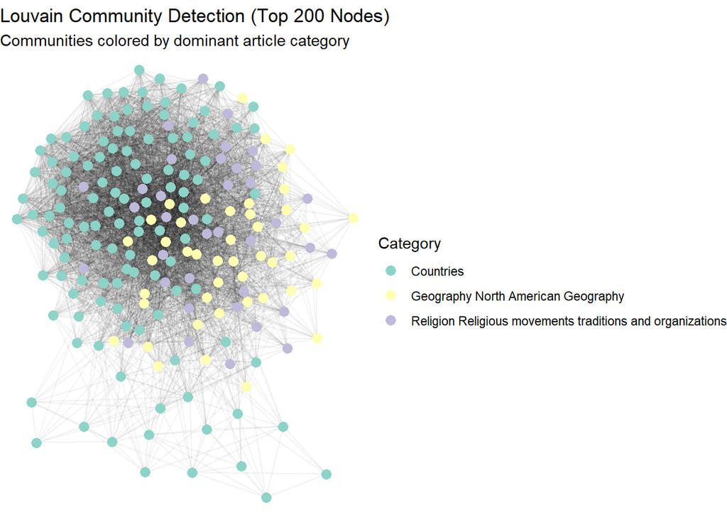

```r
set.seed(1234)

subgraph <- induced_subgraph(g, vids = names(sort(degree(g), decreasing = TRUE))[1:200])
communities_louvain <- cluster_louvain(subgraph)
V(subgraph)$community <- membership(communities_louvain)

g_tbl <- as_tbl_graph(subgraph)

node_df <- data.frame(
  name = V(subgraph)$name,
  community = V(subgraph)$community
)
node_df$title <- URLdecode(node_df$name)

node_cat <- left_join(node_df, categories, by = "title")

community_labels <- node_cat %>%
  group_by(community, category) %>%
  summarise(count = n(), .groups = "drop") %>%
  arrange(desc(count)) %>%
  group_by(community) %>%
  slice(1) %>%
  ungroup()

node_df <- left_join(node_df, community_labels, by = "community")
node_df$category <- ifelse(is.na(node_df$category), "Unlabeled", node_df$category)

top_cats <- node_df %>%
  count(category) %>%
  arrange(desc(n)) %>%
  slice(1:10) %>%
  pull(category)

node_df$category <- ifelse(node_df$category %in% top_cats, node_df$category, "Other")

g_tbl <- g_tbl %>%
  activate(nodes) %>%
  mutate(community_label = node_df$category)

ggraph(g_tbl, layout = "lgl") +
  geom_edge_link(alpha = 0.05) +
  geom_node_point(aes(color = factor(community_label)), size = 3) +
  scale_color_brewer(palette = "Set3") +
  theme_void() +
  labs(title = "Louvain Community Detection (Top 200 Nodes)",
       subtitle = "Communities colored by dominant article category",
       color = "Category")
```

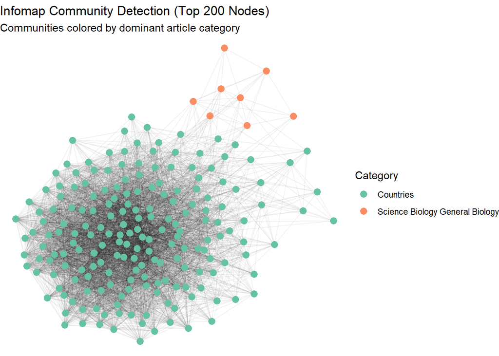

```r
set.seed(1234)

subgraph <- induced_subgraph(g, vids = names(sort(degree(g), decreasing = TRUE))[1:200])
communities_infomap <- cluster_infomap(subgraph)
V(subgraph)$community <- membership(communities_infomap)

g_tbl <- as_tbl_graph(subgraph)

node_df <- data.frame(
  name = V(subgraph)$name,
  community = V(subgraph)$community
)
node_df$title <- URLdecode(node_df$name)

node_cat <- left_join(node_df, categories, by = "title")

community_labels <- node_cat %>%
  group_by(community, category) %>%
  summarise(count = n(), .groups = "drop") %>%
  arrange(desc(count)) %>%
  group_by(community) %>%
  slice(1) %>%
  ungroup()

node_df <- left_join(node_df, community_labels, by = "community")
node_df$category <- ifelse(is.na(node_df$category), "Unlabeled", node_df$category)

top_cats <- node_df %>%
  count(category) %>%
  arrange(desc(n)) %>%
  slice(1:10) %>%
  pull(category)

node_df$category <- ifelse(node_df$category %in% top_cats, node_df$category, "Other")

g_tbl <- g_tbl %>%
  activate(nodes) %>%
  mutate(community_label = node_df$category)

ggraph(g_tbl, layout = "lgl") +
  geom_edge_link(alpha = 0.05) +
  geom_node_point(aes(color = factor(community_label)), size = 3) +
  scale_color_brewer(palette = "Set2") +
  theme_void() +
  labs(title = "Infomap Community Detection (Top 200 Nodes)",
       subtitle = "Communities colored by dominant article category",
       color = "Category")
```